# climate data

Hardy Griesbauer

17/09/2019

## Description of choosing climate stations for BGC units in the North Area

Below is R code and description used to select climate station data to generate ASMR estimates for various BGC units in the North Area.

```r
# Load libraries
library(forestDroughtTool)
library(tidyverse)
library(weathercan)
library(ggplot2)
library(here)
library(magrittr)
```

## What are the BGC units of interest in the North Area?

What units do we want to generate drought hazard estimates for?

```r
# North Area BGC units are saved in .rda file
load(here("dat","northBGC.rda"))
northBGC
```

```
##  [1] "ICHmc1"  "MHmm2"   "SBSmc2"  "CWHws2"  "ICHmc2"  "ESSFmv3" "ESSFmv1"
##  [8] "SBSwk3"  "SBSdw3"  "SBSwk2"  "ESSFmv2" "ESSFmv4" "ESSFwc3" "ESSFwk2"
## [15] "BWBSwk2" "SBSmk1"  "SBSmk2"  "SBSwk1"  "SBSmc3"  "ESSFxv1" "SBSdw1"
## [22] "SBSdw2"  "ICHvk2"  "ICHwk3"  "ICHwk4"  "ESSFwk1" "ESSFmm1" "IDFdk3"
## [29] "SBSmc1"
```

## What ECCC climate stations exist for these units?

Using a bunch of different packages, we can query the ECCC climate station data and see which ones are located in the BGC units of interest.

```r
# DON'T RUN - Takes a long time, instead use load()
# # Step 1 - Select stations in BC with daily data and assign to 'stn'
# stn<-
#   weathercan::stations %>%
#   dplyr::filter(prov=="BC" & interval=="day") %>%
#
# # Step 2 - Convert to a spatial file and merge with BGC units (this will take awhile!)
#   sf::st_as_sf(coords=c("lon","lat")) %>% # convert to spatial file
#   sf::st_set_crs(4326) %>% # set to WGS1984 datum
#   bcmaps::transform_bc_albers() %>% # set to BC albers projection
#   sf::st_join(bcmaps::bec()[,"MAP_LABEL"]) %>%  # merge with BEC
#   sf::st_drop_geometry() %>%  # drop geometry
#
# # Step 3 - Merge with BGC units of interest (above)
#   dplyr::filter(MAP_LABEL%in%northBGC) %>% # filter for BGC units of interest
#   dplyr::mutate(length=end-start+1) %>% # create a column to show record length
#   dplyr::arrange(MAP_LABEL,desc(length)) %>%
#   dplyr::select(station_name,station_id,bgc=MAP_LABEL,start,end,length)
#
# # step 4 save stn so you don't have to run above lines of code
#   save(stn,file=here("dat","stationList.rda"))

# Load station data compiled from above lines of code
  load(here("dat","stationList.rda"))

# Print to screen
  stn
```

```
## # A tibble: 154 x 6
##    station_name       station_id bgc     start   end length
##    <chr>              <fct>      <chr>   <int> <int>  <dbl>
##  1 PINK MOUNTAIN      1432       BWBSwk2  1973  1982     10
##  2 PINK MOUNTAIN 2    1430       BWBSwk2  1982  1990      9
##  3 BUCKINGHORSE RIVER 1450       BWBSwk2  1973  1977      5
##  4 TAHTSA LAKE WEST   547        CWHws2   1951  2000     50
##  5 ALICE ARM          375        CWHws2   1948  1964     17
##  6 KITSAULT MINESITE  474        CWHws2   1969  1972      4
##  7 KITSAULT MINESITE  405        CWHws2   1968  1969      2
##  8 CRANBERRY RIVER    460        CWHws2   1973  1974      2
##  9 NASS RIVER         483        CWHws2   1956  1956      1
## 10 FIRVALE            6941       CWHws2   1991  1991      1
## # ... with 144 more rows
```

## Download climate data

Need to download climate data for stations. This will take a long time, so I saved the downloaded data into an .rda file.

I printed out the station list, and manually selected stations (not shown) that have long records that span the 1961-1990 climate normal period, as much as possible. In some cases, we may want to join records.

```r
# Row numbers of stations of interest
stnRow=c(1,   2,   4,  11,  12,  15,  17,  21,  22,  36,  37,  39,  66,  67,
         72,  73,  85,  86,  87,  93, 108, 109, 123, 137, 143,
         144, 149, 150, 151, 153)

# Don't run - takes a long time.  Use load() instead
# Download data using the stnRow (this can take a long time!)
# climData<-
#   weather_dl(station_ids=stn$station_id[stnRow],interval="day") %>%
#
#   # format climate data (see below for more information)
#   select(stn=station_name,date,tmn=min_temp,tmx=max_temp,ppt=total_precip,year,month,day)

# save(climData,file=here("dat","climData.rda"))

load(here("dat","climData.rda"))
```

## Clean climate station data

We need to process missing values in the daily climate data. For this project, we: - omitted any years with >10 consecutive missing data in any climate variable;and - imputed missing data using adjacent values (closest data before and after missing value) - Leap years have 366 days, so we removed February 29 from those years to keep number of days to 365.

```r
# DON'T RUN - this takes a long time, use load() instead

# cleanECData() for each station
# x1<-by(INDICES=climData$stn,function(x) cleanECData(x),data=climData)
#
# # Formatting
# climData_cleaned<-dplyr::bind_rows(x1,.id="id")
# climData_cleaned$stn<-names(x1)[as.numeric(climData_cleaned$id)]
# rm(x1)

# # Format date columns
# climData_cleaned%<>%
#   mutate(month=as.integer(month)) %>%
#   mutate(day=as.integer(day)) %>%
#   mutate(year=as.integer(year)) %>%
#   mutate(date=paste(year,month,day,sep="-"))

# Rename columns to make it easier to pass to asmrCalc()
# climData_cleaned%<>%
#   rename(!!'tmn':=tmn_filled,!!'ppt':=ppt_filled,!!'tmx':=tmx_filled)

# save(climData_cleaned,file=here("dat","climData_cleaned.rda"))

# Load cleaned EC climate data from above lines of code
load(here("dat","climData_cleaned.rda"))

# Summarize station data
climData_cleaned %>%
  group_by(stn,year) %>%
  summarise(n()) %>%
  ungroup() %>%
  group_by(stn) %>%
  summarise(Num.years=n(),start=min(year),end=max(year))
```

```
## # A tibble: 30 x 4
##    stn                      Num.years start   end
##    <chr>                        <int> <int> <int>
##  1 ALEZA LAKE                      27  1953  1979
##  2 BARKERVILLE                    102  1889  2007
##  3 BOSS MOUNTAIN                   11  1968  1983
##  4 BOWRON LAKE                     12  1976  1989
##  5 BUFFALO LAKE                    24  1991  2015
##  6 BULLMOOSE                       15  1987  2002
##  7 DOME CREEK                      24  1922  1950
##  8 FORT BABINE                     16  1950  1971
##  9 FORT ST JAMES                  118  1895  2018
## 10 HORSEFLY LAKE GRUHS LAKE        28  1952  2015
## # ... with 20 more rows
```

## Figure showing data coverage for each station

It might be useful to produce a figure showing climate data coverage for each station and BGC unit.

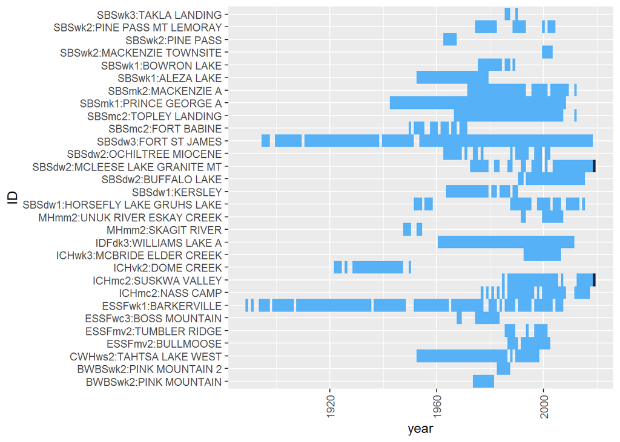

```r
climData_cleaned %>%
  group_by(stn,year) %>%
  summarise(days=n()) %>%
  inner_join(stn,by=c("stn"="station_name")) %>%
  select(stn,year,days,bgc) %>%
  ungroup() %>%
  mutate(ID=paste(bgc,stn,sep=":")) %>%
  ggplot(aes(year, ID)) +
  geom_tile(aes(fill = days))+
  theme(legend.position = "none")+
  theme(axis.text.x = element_text(angle = 90,vjust = 0.5))
```

## Histogram of ASMR classes in a BGC unit

We can plot a histogram of ASMR classes for a given BGC unit within a period of time. Might want to write a function to do this later.

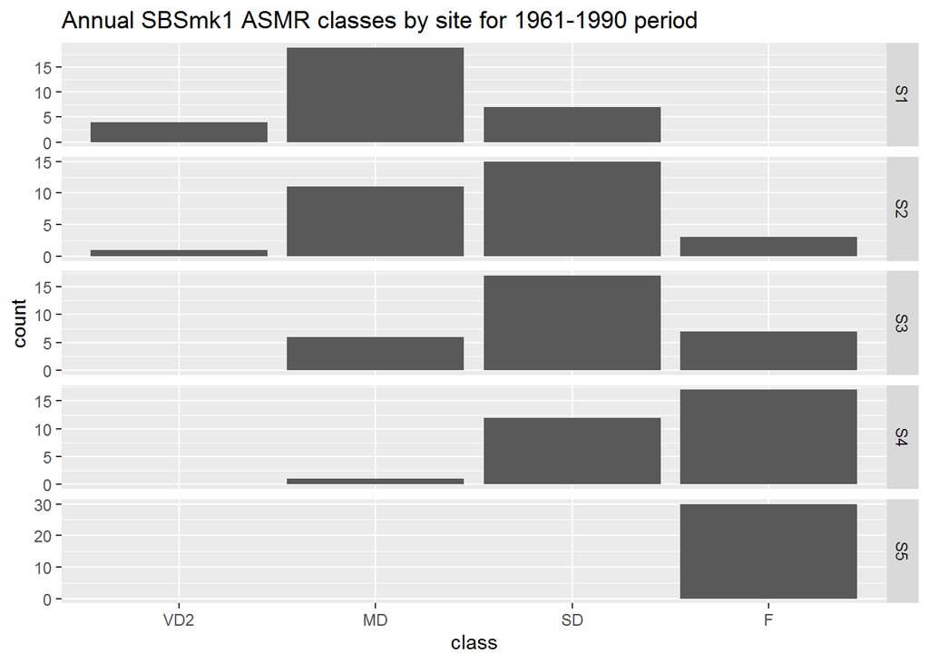

```r
# Plot out histogram of ASMR classes for five sites within SBSmk1 BGC unit from 1961-1990

  climData_cleaned %>%
  filter(stn=="PRINCE GEORGE A") %>%
  filter(year>=1961 & year<=1990) %>%
  asmrCalc() %>%
  setNames(str_remove(names(.), ".ASMR")) %>%
  group_by(year) %>%
  summarise_at(vars(S1:S5),mean) %>%
  pivot_longer(-year,names_to="site",values_to="ASMR") %>%
  mutate(class=cut(ASMR,c(0,asmrClass$asmrUL),labels=asmrClass$class)) %>%
  ggplot(aes(x=class))+
  geom_histogram(stat="count")+
  facet_grid("site",scales="free_y")+
  ggtitle("Annual SBSmk1 ASMR classes by site for 1961-1990 period")
```

## Select stations and climate data to run model

Generally, we have been summarising site ASMR using 10 years of daily climate data. The rationale for this is that we want to keep data consistent between BGC units, and we need to be able to use stations with relatively sparse data (ie. 10 years).

Based on a conversation with Vanessa, we’ve decided on the following:

1. Restrict data to 1940 and 1990. Data pre-1940 may have measurement errors, and post-1990 is starting to get into the “climate change” realm.
2. Ideally, restrict years to 1961-1990 normal period. If number of years available is less than 10, then use years from 1940-1990.
3. Select 10 years randomly from within the dataset. If there are less than 10 years of data within 1961-1990 dataset, then use all the years from 1961-1990, and add random years’ data from 1940-1960 until number of years = 10.

This is all taken care of in the asmrSelect() function in the forestDroughtTool package.

```r
# Need to change Pink Mountain2 to Pink Mountain, to concatenate the datasets
climData_cleaned %<>%
  mutate(stn=replace(stn,stn=="PINK MOUNTAIN 2","PINK MOUNTAIN"))

# Designate stations to use:
stnList=unique(climData_cleaned$stn)[c(2,3,4,6,9,11,12,16,17,19,20,21,24,26,29)]
stnID<-stn[stn$station_name%in%stnList,]
stnID<-stnID[stnID$station_id!="50820",] # get rid of extra Williams Lake data

# Print out stations used to estimate current drought hazard in North Area
stnID
```

```
## # A tibble: 15 x 6
##    station_name         station_id bgc     start   end length
##    <chr>                <fct>      <chr>   <int> <int>  <dbl>
##  1 PINK MOUNTAIN        1432       BWBSwk2  1973  1982     10
##  2 TAHTSA LAKE WEST     547        CWHws2   1951  2000     50
##  3 BULLMOOSE            1397       ESSFmv2  1982  2003     22
##  4 BOSS MOUNTAIN        569        ESSFwc3  1967  1984     18
##  5 BARKERVILLE          568        ESSFwk1  1888  2015    128
##  6 NASS CAMP            482        ICHmc2   1973  2017     45
##  7 WILLIAMS LAKE A      664        IDFdk3   1960  2012     53
##  8 KERSLEY              601        SBSdw1   1962  1992     31
##  9 OCHILTREE MIOCENE    623        SBSdw2   1963  2003     41
## 10 FORT ST JAMES        588        SBSdw3   1895  2018    124
## 11 TOPLEY LANDING       496        SBSmc2   1962  2017     56
## 12 PRINCE GEORGE A      631        SBSmk1   1942  2009     68
## 13 MACKENZIE A          1423       SBSmk2   1971  2013     43
## 14 BOWRON LAKE          564        SBSwk1   1974  1990     17
## 15 PINE PASS MT LEMORAY 1429       SBSwk2   1974  2004     31
```

Now let’s run a function to generate the dataset and export it.